# Course_Project_2 - The Effect of Vitamin C on Tooth Growth in Guinea Pigs

Zhenkun Guo

February 27, 2016

## 1. Project Introduction

The response is the length of odontoblasts (cells responsible for tooth growth) in 60 guinea pigs. Each animal received one of three dose levels of vitamin C (0.5, 1, and 2 mg/day) by one of two delivery methods, (orange juice or ascorbic acid (a form of vitamin C and coded as VC).

The goal of the analysis is to establish the relation between VC doses and tooth growth and compare the two methods of supplements (orange juice and ascorbic acid)

### 1.1. Load Necessary Library

Tooth growth data is loaded from datasets library. Also ggplot2 library is loaded for ploting. Dose level is converted to factors for convenience.

```r
library(datasets)
library(ggplot2)
data<-ToothGrowth
data$dose<-as.factor(data$dose)
```

## 2. Basic Analysis

The mean, median, standard deviation and variance are calculated for different supplement methods and different doses

```r
data_summary<-aggregate(data=data,len~supp+dose,FUN = mean)
names(data_summary)<-c("Supplement Type","Dose","Len_Mean")
data_summary$Len_Median<-aggregate(data=data,len~supp+dose,FUN = median)$len
data_summary$Len_Std<-aggregate(data=data,len~supp+dose,FUN = sd)$len
data_summary$Len_Var<-aggregate(data=data,len~supp+dose,FUN = var)$len
data_summary
```

```
##   Supplement Type Dose Len_Mean Len_Median  Len_Std   Len_Var
## 1              OJ  0.5    13.23      12.25 4.459709 19.889000
## 2              VC  0.5     7.98       7.15 2.746634  7.544000
## 3              OJ    1    22.70      23.45 3.910953 15.295556
## 4              VC    1    16.77      16.50 2.515309  6.326778
## 5              OJ    2    26.06      25.95 2.655058  7.049333
## 6              VC    2    26.14      25.95 4.797731 23.018222
```

From this point, orange juice induces longer tooth comparing to VC for 0.5 or 1 mg/day. However, for 2mg/day, orange juice and VC are equaly powerful. Also, the intake dose of VC is positively correlated with tooth length.

## 3. Explotary Analysis

Boxplots are generated to give an intuitive concept of the data

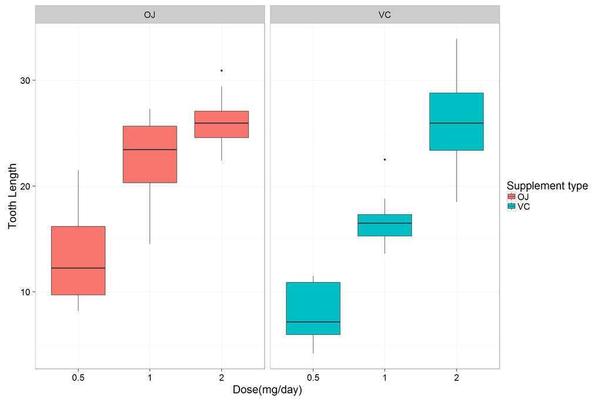

```r
figure <- ggplot(data, aes(x = dose, y = len, fill = supp))
figure <- figure + geom_boxplot()
figure <- figure + facet_grid(. ~ supp)
figure<-figure+theme_bw(base_size = 20)+xlab("Dose(mg/day)")+ylab('Tooth Length')
figure<-figure+guides(fill=guide_legend(title="Supplement type"))
print(figure)
```

As shown in the graph, with higher dose, the tooth length increases. Also orange juice has better effects than vc for lower dose but almost the same for 2mg/day.

## 4. Hyopothesis Tests

### 4.1. Comparing Different Intake Doses

#### 4.1.1. For Orange Juise Method

Comparing 0.5mg/day and 1mg/day

```r
t.test(len~dose,data = subset(data,dose %in% c(0.5,1) & supp=="OJ"))
```

```
##
##  Welch Two Sample t-test
##
## data:  len by dose
## t = -5.0486, df = 17.698, p-value = 8.785e-05
## alternative hypothesis: true difference in means is not equal to 0
## 95 percent confidence interval:
##  -13.415634  -5.524366
## sample estimates:
## mean in group 0.5   mean in group 1
##             13.23             22.70
```

p-value is 8E-5<<0.01 and the 95% confidence interval is all below 0. According to these results, we can conclue that 1mg/day has a stronger effect on tooth growth than 0.5mg/day.

Then compare 1mg/day and 2mg/day

```r
t.test(len~dose,data = subset(data,dose %in% c(1,2) & supp=="OJ"))
```

```
##
##  Welch Two Sample t-test
##
## data:  len by dose
## t = -2.2478, df = 15.842, p-value = 0.0392
## alternative hypothesis: true difference in means is not equal to 0
## 95 percent confidence interval:
##  -6.5314425 -0.1885575
## sample estimates:
## mean in group 1 mean in group 2
##           22.70           26.06
```

p-value is 0.0392<0.05 and the 95% confidence interval is all below 0. According to these results, we can conclue that 2mg/day has a stronger effect on tooth growth than 1mg/day.However, the increasement of toolth growth is not as significant as the increasement from 0.5mg/day to 1mg/day. One possible explanation of the phenomenon is that the vitamin C can be absorbed within 2mg/day has exceeded the saturation limit.

### 4.1.2. For VC Method

Comparing 0.5mg/day and 1mg/day

```r
t.test(len~dose,data = subset(data,dose %in% c(0.5,1) & supp=="VC"))
```

```
##
##  Welch Two Sample t-test
##
## data:  len by dose
## t = -7.4634, df = 17.862, p-value = 6.811e-07
## alternative hypothesis: true difference in means is not equal to 0
## 95 percent confidence interval:
##  -11.265712  -6.314288
## sample estimates:
## mean in group 0.5   mean in group 1
##              7.98             16.77
```

p-value is 6.8E-7<<0.01 and the 95% confidence interval is all below 0. According to these results, we can conclue that 1mg/day has a stronger effect on tooth growth than 0.5mg/day.

Then compare 1mg/day and 2mg/day

```r
t.test(len~dose,data = subset(data,dose %in% c(1,2) & supp=="VC"))
```

```
##
##  Welch Two Sample t-test
##
## data:  len by dose
## t = -5.4698, df = 13.6, p-value = 9.156e-05
## alternative hypothesis: true difference in means is not equal to 0
## 95 percent confidence interval:
##  -13.054267  -5.685733
## sample estimates:
## mean in group 1 mean in group 2
##           16.77           26.14
```

p-value is 9E-5<<0.01 and the 95% confidence interval is all below 0. According to these results, we can conclue that 2mg/day has a stronger effect on tooth growth than 1mg/day.Different from orange juice method, the increasement between 2mg/day and 1mg/day is as significant as the increasement between 0.5mg/day and 1mg/day. Based on this fact, we can assume VC method reaches its absorption limit later than orange juice method.

### 4.2. Comparing Two Methods of Supplement

Two samples t-test is performed between orange juice and vc supplement methods for each dose level.

For 0.5mg/day

```r
t.test(len~supp,data = subset(data,dose==0.5))
```

```
##
##  Welch Two Sample t-test
##
## data:  len by supp
## t = 3.1697, df = 14.969, p-value = 0.006359
## alternative hypothesis: true difference in means is not equal to 0
## 95 percent confidence interval:
##  1.719057 8.780943
## sample estimates:
## mean in group OJ mean in group VC
##            13.23             7.98
```

p-value is 0.006<0.01 and the 95% confidence interval is all above 0. According to these results, we can conclude that orange juice as a supplement method has a stronger effect on tooth length than vc.

For 1mg/day

```r
t.test(len~supp,data = subset(data,dose==1))
```

```
##
##  Welch Two Sample t-test
##
## data:  len by supp
## t = 4.0328, df = 15.358, p-value = 0.001038
## alternative hypothesis: true difference in means is not equal to 0
## 95 percent confidence interval:
##  2.802148 9.057852
## sample estimates:
## mean in group OJ mean in group VC
##            22.70            16.77
```

p-value is 0.001<0.01 and the 95% confidence interval is all above 0. According to these results, we can conclude that orange juice as a supplement method has a stronger effect on tooth length than vc.

For 2mg/day

```r
t.test(len~supp,data = subset(data,dose==2))
```

```
##
##  Welch Two Sample t-test
##
## data:  len by supp
## t = -0.046136, df = 14.04, p-value = 0.9639
## alternative hypothesis: true difference in means is not equal to 0
## 95 percent confidence interval:
##  -3.79807  3.63807
## sample estimates:
## mean in group OJ mean in group VC
##            26.06            26.14
```

p-value is 0.9639 and the 95% confidence interval includes 0. According to these results, there is no significant evidence to say there is any difference between the two supplement methods.In other words, we can consider that the effects of the two supplement methods are the same.

## 5. Assumptions and Conclusions

### 5.1. Assumptions

Any above or following statistical inference and conclusion is based on the following assumptions.

1. All the pigs have the same or similar tooth length at the beginning before taking any Vitamin C.
2. Vitamin C has the same effects on every pig for tooth growth.
3. Besides Vitamin C, other feeding or raising conditions are the same for every pig involved.

### 5.2. Conclusions

Based on the tests and analysis above, conclusion listed can be made:

1. The tooth length is positively correlated to the dose of Vitamin C intake for both supplement methods. In other words, the higher dose of Vitamin C the longer tooth length will grow.
2. Orange juice as a supplement method has stronger effects on tooth growth at low Vitamin C dose (0.5mg/day, 1mg/day) than vc but has similar effects for high dose (2mg/day). A possible explaination is that, only a certain portion of Vitamin C (usable Vitamin C) in Orange juice and vc can be absorbed and the portion of orange juice is higher than vc. The pigs have absoption limit and no more Vitamin C can be absorbed beyond this limit. When the pigs intake a high dose (2mg/day), the usable Vitamin C contained has exceeded the limit. That explains why orange juice and vc have similar effects at high dose.